# Visualização de dados georreferenciados.

# R base

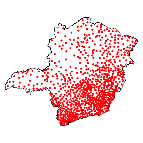

```r
require(mapsBR)
data(regMun)
data(regUF)
mg_uf  <- subset(regUF, COD == "MG")
mg_mun <- coordinates(subset(regMun, UF == "MG"))

par(mar= rep(0, 4), bg = 'transparent')
plot(mg_uf)
points(mg_mun[, 1], mg_mun[, 2], pch = 19, cex = 0.6, col = 'red')
box()
```

# spGoogle

# spGoogle

## Um pouco de história

- O pacote **spGoogle** surgiu através do projeto  [Arouca - DCC](https://arouca.unasus.gov.br/plataformaarouca/Home.app).
- A Plataforma Arouca é o Sistema de Informação dos Profissionais de Saúde do Brasil.
- Nela é possível acessar mapas de oportunidades educacionais, sejam de curta ou longa duração, de caráter mais prático ou acadêmico, presenciais ou a distância que são financiadas com recursos públicos para qualificar os trabalhadores do SUS.
- Antes do **spGoogle** foi desenvolvido o pacote **aRouca** para suprir as necessidades de visualizações georreferenciadas da Plataforma Arouca.
- **aRouca** `\(\rightarrow\)` **spGoogle**.

# spGoogle

- O objetivo do pacote é fornecer aos usuários uma forma simples de construir mapas elegantes e interativos.
- Criar mapas utilizando o Google Maps não é uma tarefa muito simples para nós estatísticos.
- Sendo assim criamos um pacote com apenas duas funções `spGplot` e `spRplot`.
- `sp`**`R`**`plot`: mapas estáticos, porém com a interface do Google Maps.
- `sp`**`G`**`plot`: mapas interativos diretos no Google Maps.

# Tipos de mapas

- Mapa de áreas `\(\rightarrow\)` **`SpatialPolygonsDataFrame()`**
- Mapa de pontos `\(\rightarrow\)` **`SpatialPointsDataFrame()`**
- Mapa de linhas `\(\rightarrow\)` **`SpatialLinesDataFrame()`**
- Mapa de grid ou pixel `\(\rightarrow\)`  **`SpatialGridDataFrame()`**

# Instalando do pacote **spGoogle**

- O pacote **spGoogle** fica no repositório do [GitHub](https://github.com/) na página  [spGoogle](github.com/lgsilvaesilva/spGoogle) - github.com/lgsilvaesilva/spGoogle.

- Para instalar diretamente do GitHub é precio o pacote `devtools`

```r
> install.packages(devtools)
> library('devtools')
> install_github('lgsilvaesilva/spGoogle')
```

```r
> library(spGoogle)
```

# leaflet

# leaflet

- É um pacote `open-source` baseado em bibliotecas JavaScript para construção de mapas interativos;
- Utilizado pelo **The New York Times** para criação de mapas;
- As visualização são rendenrizadas no OpenSteetMap.
- Para instalar o pacote, bastar rodar o comando abaixo.

```r
> install.packages("leaflet")
> library(leaflet) # ou require(leaflet)
```

# Exemplos: pontos

```r
library(leaflet)
latlong_rede <- readRDS("~/Dropbox/Pesquisa-Ajuda/r-development/unimed-spatial/dados/lat_long_rede_atendimento.rds")
leaflet() %>%
  addTiles() %>%
  addMarkers(lng=latlong_rede$lng, lat=latlong_rede$lat)
```

[interactive chart not shown]

# Exemplos: pontos

```r
library(leaflet)
leaflet() %>%
  addTiles() %>%
  addMarkers(lng=latlong_rede$lng,
             lat=latlong_rede$lat,
             popup = latlong_rede$razao_social,
             label = latlong_rede$tipo)
```

[interactive chart not shown]

# Exemplos: heatmap

```r
library(leaflet.extras)
leaflet(quakes) %>%
  addProviderTiles(providers$CartoDB.DarkMatter) %>%
  setView( 178, -20, 5 ) %>%
  addHeatmap(lng = ~long, lat = ~lat, intensity = ~mag,
             blur = 20, max = 0.05, radius = 15)
```

[interactive chart not shown]

# Exemplos: polygons

```r
data(rio)
bins <- c(0, 1, 2, 3, 4, 5, Inf)
pal <- colorBin("YlOrRd", domain = rio$SMR, bins = bins)

leaflet(rio) %>%
  addProviderTiles(providers$OpenStreetMap.Mapnik) %>%
  addPolygons(fillColor = ~pal(SMR),
              weight = 1.5,
              opacity = 1,
              fillOpacity = 0.7,
              color = "gray",
               highlight = highlightOptions(
    weight = 5,
    color = "#666",
    dashArray = "",
    fillOpacity = 0.7,
    bringToFront = TRUE),
    label = sprintf("%s - SMR: %s", rio$Name, round(rio$SMR, 3)),
    labelOptions = labelOptions(
    style = list("font-weight" = "normal", padding = "3px 8px"),
    textsize = "15px",
    direction = "auto")) %>%
  addLegend(pal = pal, values = ~SMR, opacity = 0.7, title = NULL,
  position = "bottomright")
```

# Exemplos: polygons

[interactive chart not shown]

# Conclusão

# Conclusão

- Os pacotes `spGoogle` e `leaflet` produzem mapas interativos de forma simples e intuitiva;

- Tantos os pacotes quanto o software `R` são **open-source**, ou seja, não nenhum custo ao utilizar estas ferramentas;

- Com poucas linhas de código é possível customizar os mapas em um padrão da empresa;

- Estes mapas podem ser integrados em aplicações Web, por exemplo, aplicativos `Shiny`.

# Obrigado

lgsilvaesilva@gmail.com

(31) 9 9450-5501